# 02_predictive_modelling

Maryam Shojaei Shahrokhabadi

2026-01-07

```r
knitr::opts_chunk$set(echo = FALSE)
```

## 1. Introduction

The leukemia dataset contains expression measurements for 7,128 genes in 72 patients with one of two types of acute leukemia: 47 with acute lymphoblastic leukemia (ALL) and 25 with acute myeloid leukemia (AML). The aim of this analysis is to build a model that predicts the leukemia type of a patient from their gene expression profile, and to evaluate how well it performs. The outcome is coded as $Y_i = 1$ if patient $i$ has AML and $Y_i = 0$ if they have ALL, and $X_{ij}$ denotes the expression of gene $j$ in patient $i$. The goal is to estimate $P(Y_i = 1)$ as a function of the expression data.

Two approaches are compared. The first uses one gene at a time: a separate logistic regression is fitted for each gene, and the best single genes are evaluated as predictors. The second, supervised principal components (SPCA), combines information from several genes into a single summary score before fitting the model.

Predictive performance is measured with three quantities: the misclassification error (MCE), the proportion of patients assigned to the wrong class; the sensitivity, the proportion of AML patients correctly identified; and the specificity, the proportion of ALL patients correctly identified

## 2. Gene-Specific Logistic Regression

### 2.1 Model

For each gene $j$, a logistic regression model relates the probability of AML to the expression of that gene:

$$P(Y_i = 1 \mid X_{ij}) = \frac{e^{\alpha + \beta_j X_{ij}}}{1 +
e^{\alpha + \beta_j X_{ij}}}$$

The parameter $\beta_j$ describes the effect of gene $j$: a positive value means that higher expression is associated with a higher probability of AML, and a negative value with a higher probability of ALL. For each gene, the hypothesis $H_0: \beta_j = 0$ (no association with leukemia type) is tested against $H_1: \beta_j \neq 0$ using a Wald test.

### 2.2 Ranking the Genes

The purpose of fitting 7,128 models is not to test each gene formally, but to rank the genes by the strength of their association with leukemia type. Figure 1 shows the resulting p-values. The histogram has a very large peak close to zero, far stronger than in the prostate data, which indicates that a large number of genes differ between ALL and AML.

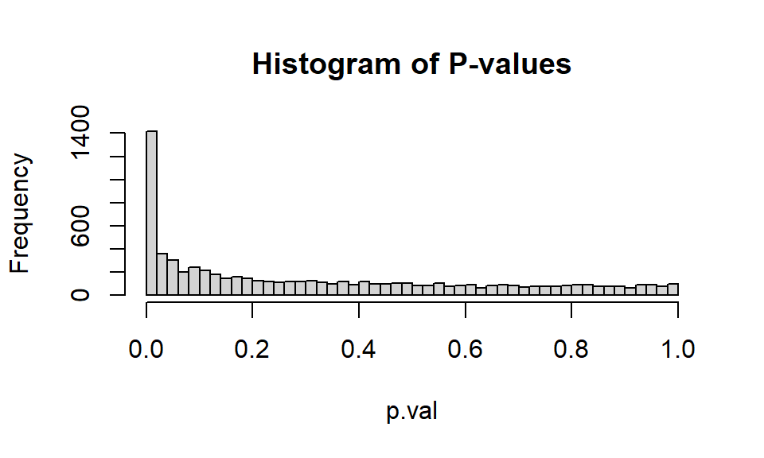

**Figure 1. Histogram of the raw p-values from the 7,128 gene-specific models.**

Figure 2 shows the fitted models for the four top-ranked genes. Each point is a patient, plotted at 1 for AML and 0 for ALL, and the red curve is the estimated probability of AML. For all four genes, the probability of AML rises with expression, and the two classes are largely separated, although some patients fall on the “wrong” side of each curve.

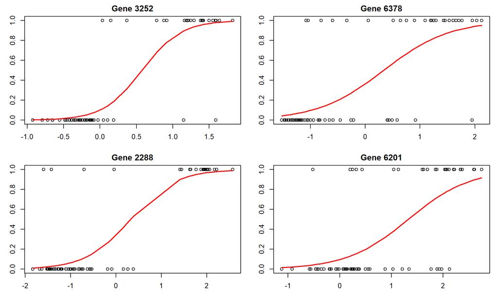

**Figure 2. Fitted logistic regression curves for the four genes with the smallest p-values.**

### 2.3 Prediction and Performance

Once the model is fitted, the estimated probability of AML for patient $i$ is

$$\hat{P}(Y_i = 1 \mid X_{ij}) = \frac{e^{\hat{\alpha}_j + \hat{\beta}_j
X_{ij}}}{1 + e^{\hat{\alpha}_j + \hat{\beta}_j X_{ij}}}$$

and a patient is classified as AML if this probability is greater than 0.5, and as ALL otherwise.

Table 1 shows the performance of the four top-ranked genes, each used on its own. All four have p-values below the Bonferroni threshold of $0.05 / 7128 \approx 7.0 \times 10^{-6}$, so their association with leukemia type remains significant even under the strictest multiple testing correction. The best single genes misclassify about 7% of patients. Specificity is consistently higher than sensitivity, meaning that the models recognise ALL patients more reliably than AML patients. This is partly a consequence of the class imbalance: with 47 ALL and only 25 AML patients, the fitted probabilities are pulled towards ALL.

**Table 1. Performance of the four top-ranked genes, each used as the only predictor.**

| Gene | P_value | MCE | Sensitivity | Specificity |
| --- | --- | --- | --- | --- |
| 3252 | 1.31e-06 | 0.0694444 | 0.88 | 0.9574468 |
| 6378 | 1.62e-06 | 0.1805556 | 0.76 | 0.8510638 |
| 2288 | 3.65e-06 | 0.0694444 | 0.84 | 0.9787234 |
| 6201 | 3.85e-06 | 0.1805556 | 0.72 | 0.8723404 |

## 3. Supervised Principal Components (SPCA)

### 3.1 Motivation

Single-gene models have two important limitations. They use only one gene at a time, so any additional information in other genes is ignored. And they ignore the correlation between genes: genes involved in the same biological process often have similar expression patterns, so the top-ranked genes are likely to carry overlapping information.

Supervised principal components addresses both problems. It first selects the genes most strongly related to the outcome, and then summarises their shared variation with principal component analysis. The resulting component is a weighted combination of the selected genes that can be used as a single predictor, which avoids fitting a model with more predictors than patients.

### 3.2 Procedure

The analysis followed four steps:

1. Rank all genes by their p-values from the gene-specific logistic models (Section 2.2).
2. Select the top $K = 10$ genes, reducing the data from a 7,128 × 72 matrix to a 10 × 72 matrix.
3. Perform principal component analysis on the selected genes (using the correlation matrix, so that all genes contribute on the same scale) and compute the first principal component score $U_i$ for each patient.
4. Fit a logistic regression with this score as the only predictor:

$$P(Y_i = 1 \mid U_i) = \frac{e^{\alpha + \beta U_i}}{1 + e^{\alpha +
\beta U_i}}$$

### 3.3 Results

Figure 3 shows the variance explained by each principal component of the 10 selected genes. The first component explains 62.90% of the total variability, far more than any other component. This confirms that the top-ranked genes are strongly correlated and that a single component captures most of their information.

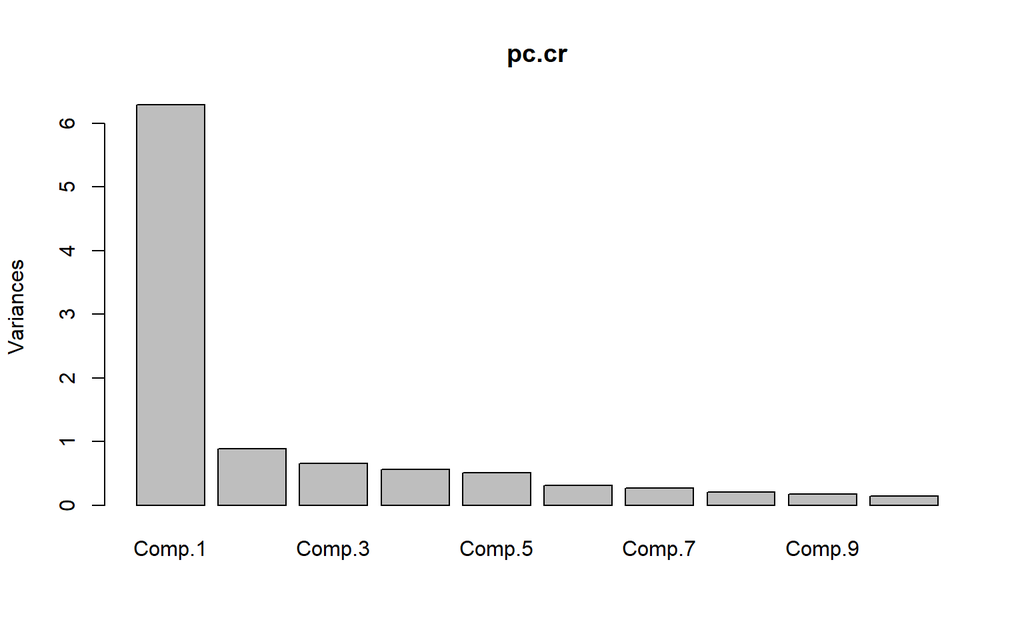

**Figure 3. Variance explained by each principal component of the 10 selected genes.**

Figure 4 shows the logistic regression on the first principal component. Compared with the single-gene models in Figure 2, the two classes are much more clearly separated, and the fitted curve rises steeply, so most patients receive a predicted probability close to 0 or 1.

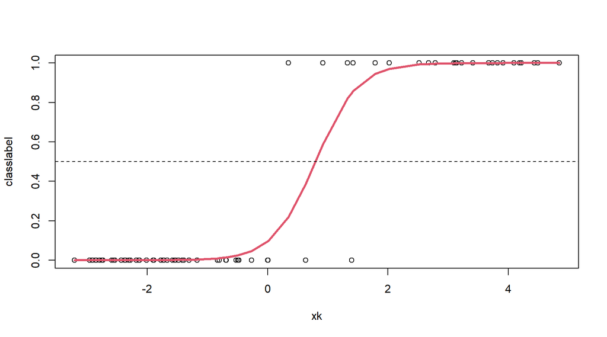

**Figure 4. Logistic regression of leukemia type on the first principal component score. The dashed line marks the 0.5 classification threshold.**

Table 2 summarises the performance of the SPCA model. It misclassifies 3% of patients, compared with 7% for the best single gene, and the gap between sensitivity and specificity is much smaller than for the single-gene models.

**Table 2. Performance of the SPCA model.**

| Feature | MCE | Sensitivity | Specificity |
| --- | --- | --- | --- |
| PC1 | 0.03 | 0.96 | 0.98 |

## 4. Conclusion

Several individual genes are strongly associated with leukemia type and can, on their own, classify most patients correctly. Combining the ten top-ranked genes through supervised principal components improved prediction further, reducing the misclassification error from 7% to 3% and giving a better balance between sensitivity and specificity. Because the selected genes are highly correlated, a single component was enough to capture most of their predictive information.

One limitation should be noted. All error rates in this analysis were computed on the same 72 patients that were used to rank the genes and fit the models. They therefore measure how well the models fit these data, and are likely to be optimistic for new patients. A fair estimate of predictive performance requires that gene selection and model fitting be repeated within a cross-validation scheme; this is done in the gene signature analysis.